# Modelling the invasive American Mink in the Pyrenees

## The system

In the Pyrenees, several small carnivores compete for habitat and prey. Of these, the [European mink](https://en.wikipedia.org/wiki/European_mink) is highly threatened, due to competition with the invasive [American mink](https://en.wikipedia.org/wiki/American_mink). The population of European Mink in the Pyrenees is one of the last remaining in Europe, and conservation of the species depends on us finding a way to mitigate the threats in this region.

The European and American mink are both semi-aquatic [mustelids](https://en.wikipedia.org/wiki/Mustelidae) which have relatively small territories on rivers or coasts. They hunt small rodents, birds, fish, and crustaceans. Despite the similarities that have led to their common name, they are members of distinct evolutionary lineages, with the European mink being more closely related to weasels and ferrets than the American mink. Therefore, their similar lifestyles are an example of [convergent evolution](https://en.wikipedia.org/wiki/Convergent_evolution).

## A simple model

To start with, let’s imagine how the population of the European mink looked before the invasive species arrived. We can imagine that there is a certain amount of mink that can be supported by the environment (the [carrying capacity](https://en.wikipedia.org/wiki/Carrying_capacity)) and that the population of mink grows when there are a lower number of individuals than the carrying capacity will support. If the population exceeds the carrying capacity, then more individuals will die than will survive (due to limited resources) and the population will shrink. This model is called the [logistic model](https://en.wikipedia.org/wiki/Logistic_function#In_ecology:_modeling_population_growth), and it’s written like this:

[figure not shown]

This equation tells us how the population changes over time.

[figure not shown]

is the number of mink at any given time.

[figure not shown]

is the carrying capacity – let’s assume that the environment can support 1,000 individuals for now.

[figure not shown]

is the per-capita [*intrinsic growth rate*](https://en.wikipedia.org/wiki/Population_dynamics#Intrinsic_rate_of_increase), we can get the value for this from the litter size of the mink. The European mink has an average litter size of five kits [1], so the per-capita rate of increase

[figure not shown]

is

[figure not shown]

(since only females bear offspring). The intrinsic rate growth rate

[figure not shown]

. The term

[figure not shown]

decreases as

[figure not shown]

gets close to

[figure not shown]

– this means that fewer and fewer offspring survive until adulthood as we get closer to the carrying capacity – which makes sense, since there are fewer resources remaining.

Let’s model this[2].

```r
logistic <- function(X) {
        # Define the parameters.
        K <- 1000
        r <- log(2.5)
        # Calculate the result from the model.
        res <- r * X * (1 - X / K)
        return(res)
}
```

```r
res <- run_simulation(
        logistic,   # Use our model.
        X = 10,     # Start with 10 individuals.
        N = 20      # Run it for 20 time steps
)
```

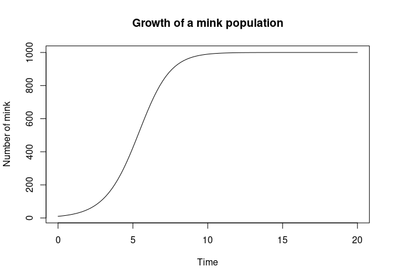

```r
# Plot our results.
plot(
        res[, 1], res[, 2],
        type = "l",    # For a line graph
        xlab = "Time",
        ylab = "Number of mink",
        main = "Growth of a mink population"
)
```

We can see that the population initially grows very quickly, before levelling out at the carrying capacity. If we look closely, we can see that it takes only about 10 timesteps to get to 1,000 individuals! The power of [exponential growth](https://en.wikipedia.org/wiki/Exponential_growth#Biology).

**Exercise:** If the average litter size is reduced to three kits – perhaps by some chemical pollutant – how long will it now take the population of mink to reach the carrying capacity?